# draft for Intro to R class

john

9/1/2016

# Intro to R

## Housekeeping

#### Joel - PPT

1. welcome
2. what is r
3. what is RStudio
4. What is a Project
5. What is Docker

```r
require(rmarkdown)
require(dplyr)
```

```r
require(ggplot2)
```

## Data Management

### Load Data

```r
data("mtcars")         # load specified data set
```

#### NOTES

- ENVIRONMENT PANE: Import Dataset
  - FILES PANE: Files–Upload
- `readr::read_csv`
- `readxl`
- To get help, use precede command with ‘?’
  - `?mtcars`

### View your data in a grid

```r
View(mtcars)
```

##### Notes

- An exploratory convenience, not “reproducible” in the sense of generating a report or leaving a trail of your work
- Environment Pane has information about data objects
- View output has sorting

### Structure of Data Object

```r
str(mtcars)
```

```
## 'data.frame':    32 obs. of  11 variables:
##  $ mpg : num  21 21 22.8 21.4 18.7 18.1 14.3 24.4 22.8 19.2 ...
##  $ cyl : num  6 6 4 6 8 6 8 4 4 6 ...
##  $ disp: num  160 160 108 258 360 ...
##  $ hp  : num  110 110 93 110 175 105 245 62 95 123 ...
##  $ drat: num  3.9 3.9 3.85 3.08 3.15 2.76 3.21 3.69 3.92 3.92 ...
##  $ wt  : num  2.62 2.88 2.32 3.21 3.44 ...
##  $ qsec: num  16.5 17 18.6 19.4 17 ...
##  $ vs  : num  0 0 1 1 0 1 0 1 1 1 ...
##  $ am  : num  1 1 1 0 0 0 0 0 0 0 ...
##  $ gear: num  4 4 4 3 3 3 3 4 4 4 ...
##  $ carb: num  4 4 1 1 2 1 4 2 2 4 ...
```

#### Similar Commands

- `tbl_df()` # tibbles are modernized data frames
- `dim()` # dimensions
- `class()` # data type

### Missing Data

#### Joel

- `is.na()`
- `anyNA()`
- `na.omit()`

```r
nadata <- c("cat", "dog", NA_character_, "fish", "snake")
anyNA(nadata)
```

```
## [1] TRUE
```

## Data Reshaping

#### John

dplyr is a widely adopted r package and makes it easy to use english verbs to reshape your data.

### Arrange

```r
arrange(mtcars, cyl, desc(mpg), desc(hp), wt)
```

```
##     mpg cyl  disp  hp drat    wt  qsec vs am gear carb
## 1  33.9   4  71.1  65 4.22 1.835 19.90  1  1    4    1
## 2  32.4   4  78.7  66 4.08 2.200 19.47  1  1    4    1
## 3  30.4   4  95.1 113 3.77 1.513 16.90  1  1    5    2
## 4  30.4   4  75.7  52 4.93 1.615 18.52  1  1    4    2
## 5  27.3   4  79.0  66 4.08 1.935 18.90  1  1    4    1
## 6  26.0   4 120.3  91 4.43 2.140 16.70  0  1    5    2
## 7  24.4   4 146.7  62 3.69 3.190 20.00  1  0    4    2
## 8  22.8   4 140.8  95 3.92 3.150 22.90  1  0    4    2
## 9  22.8   4 108.0  93 3.85 2.320 18.61  1  1    4    1
## 10 21.5   4 120.1  97 3.70 2.465 20.01  1  0    3    1
## 11 21.4   4 121.0 109 4.11 2.780 18.60  1  1    4    2
## 12 21.4   6 258.0 110 3.08 3.215 19.44  1  0    3    1
## 13 21.0   6 160.0 110 3.90 2.620 16.46  0  1    4    4
## 14 21.0   6 160.0 110 3.90 2.875 17.02  0  1    4    4
```

[output cut: 18 more lines]

### Filter

```r
sixcyls <- filter(mtcars, cyl == 6)
```

### Mutate

Add columns

```r
sixcyls <- mutate(sixcyls, dispWt = disp / wt)
```

### Select

```r
sixcyls <- select(sixcyls, mpg:wt)
```

### Count

```r
tbl_df(sixcyls) %>%
  count(hp)
```

```
## # A tibble: 4 × 2
##      hp     n
##   <dbl> <int>
## 1   105     1
## 2   110     3
## 3   123     2
## 4   175     1
```

#### Exercise 2

**Data Management**

#### Joel

1. `arrange()`
2. `filter()`
3. `mutate()`
4. `select()`
5. `count()`

### Put it all together

```r
mutate(mtcars, rownames(mtcars)) %>%
  rename(makeModel = `rownames(mtcars)`) %>%
  filter(cyl >= 4, cyl <= 6) %>%
  select(makeModel, mpg:wt) %>%
  mutate(dispWt = disp / wt) %>%
  arrange(desc(mpg), wt)
```

```
##         makeModel  mpg cyl  disp  hp drat    wt   dispWt
## 1  Toyota Corolla 33.9   4  71.1  65 4.22 1.835 38.74659
## 2        Fiat 128 32.4   4  78.7  66 4.08 2.200 35.77273
## 3    Lotus Europa 30.4   4  95.1 113 3.77 1.513 62.85525
## 4     Honda Civic 30.4   4  75.7  52 4.93 1.615 46.87307
## 5       Fiat X1-9 27.3   4  79.0  66 4.08 1.935 40.82687
## 6   Porsche 914-2 26.0   4 120.3  91 4.43 2.140 56.21495
## 7       Merc 240D 24.4   4 146.7  62 3.69 3.190 45.98746
## 8      Datsun 710 22.8   4 108.0  93 3.85 2.320 46.55172
## 9        Merc 230 22.8   4 140.8  95 3.92 3.150 44.69841
## 10  Toyota Corona 21.5   4 120.1  97 3.70 2.465 48.72211
## 11     Volvo 142E 21.4   4 121.0 109 4.11 2.780 43.52518
## 12 Hornet 4 Drive 21.4   6 258.0 110 3.08 3.215 80.24883
## 13      Mazda RX4 21.0   6 160.0 110 3.90 2.620 61.06870
## 14  Mazda RX4 Wag 21.0   6 160.0 110 3.90 2.875 55.65217
## 15   Ferrari Dino 19.7   6 145.0 175 3.62 2.770 52.34657
## 16       Merc 280 19.2   6 167.6 123 3.92 3.440 48.72093
## 17        Valiant 18.1   6 225.0 105 2.76 3.460 65.02890
## 18      Merc 280C 17.8   6 167.6 123 3.92 3.440 48.72093
```

## Basic Vis

When in the data exploratory phase, you can quickly generate very basic visualizations with minmal effort. Your visualiations then appear in the Viewer Pane. While you may not want to share these visualizations, the simplicity of generating quick histograms can help you understand your data as you begin thinking about your analysis.

Type these commans into your console.

To generate

- Histogram: `hist(mtcars$mpg)`
- Scatterplot: `plot(mtcars$wt, mtcars$mpg)`
- Barplot: `barplot(table(mtcars$cyl))`

## Better Vis via ggplot2

### ggplot2 Scatter Plot

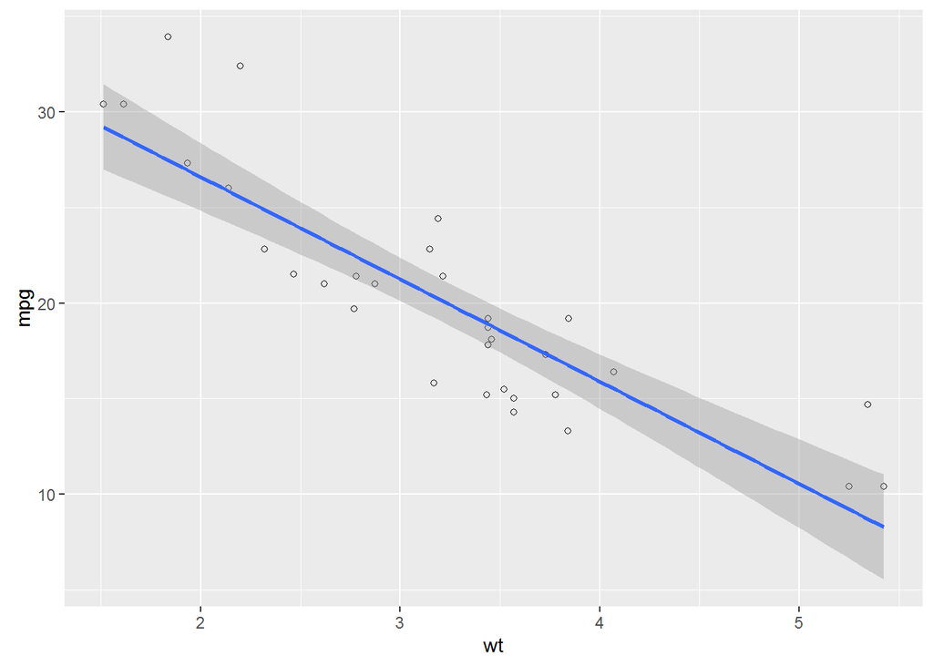

```r
ggplot(mtcars, aes(x = wt, y = mpg)) +
  geom_point(shape = 1) +
  geom_smooth(method = lm)
```

more info on ggplot scatterplots

### ggplot2 Bar Graph

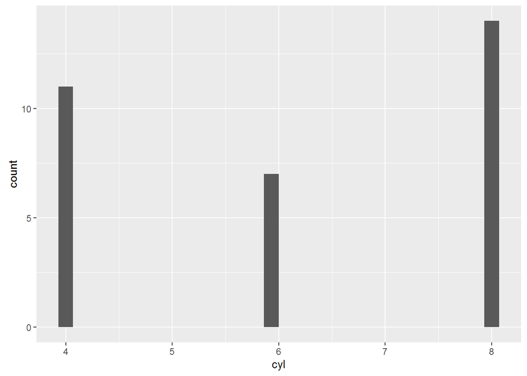

```r
ggplot(data=mtcars, aes(x = cyl)) +
    geom_bar(stat="bin")
```

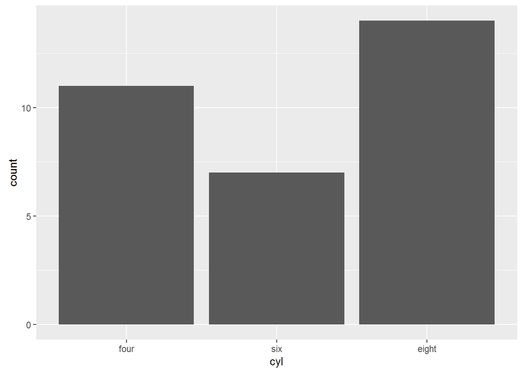

```r
mutate(mtcars, cyl = factor(cyl, labels = c("four","six","eight"))) %>%
  ggplot(aes(x = cyl)) +
    geom_bar(stat="count")
```

More Information on ggplot bar and line graphs

### ggplot2 Histogram

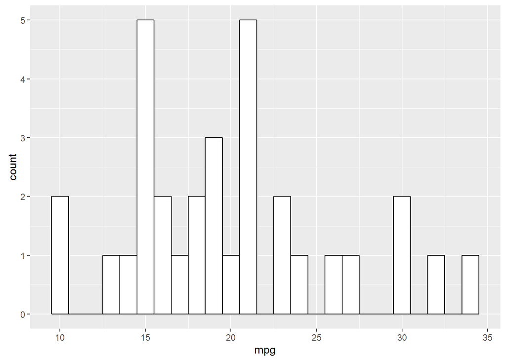

```r
ggplot(mtcars, aes(x = mpg)) +
    geom_histogram(binwidth=1, colour="black", fill="white")
```

More info on ggplot histograms

### ggplot2 Line graph

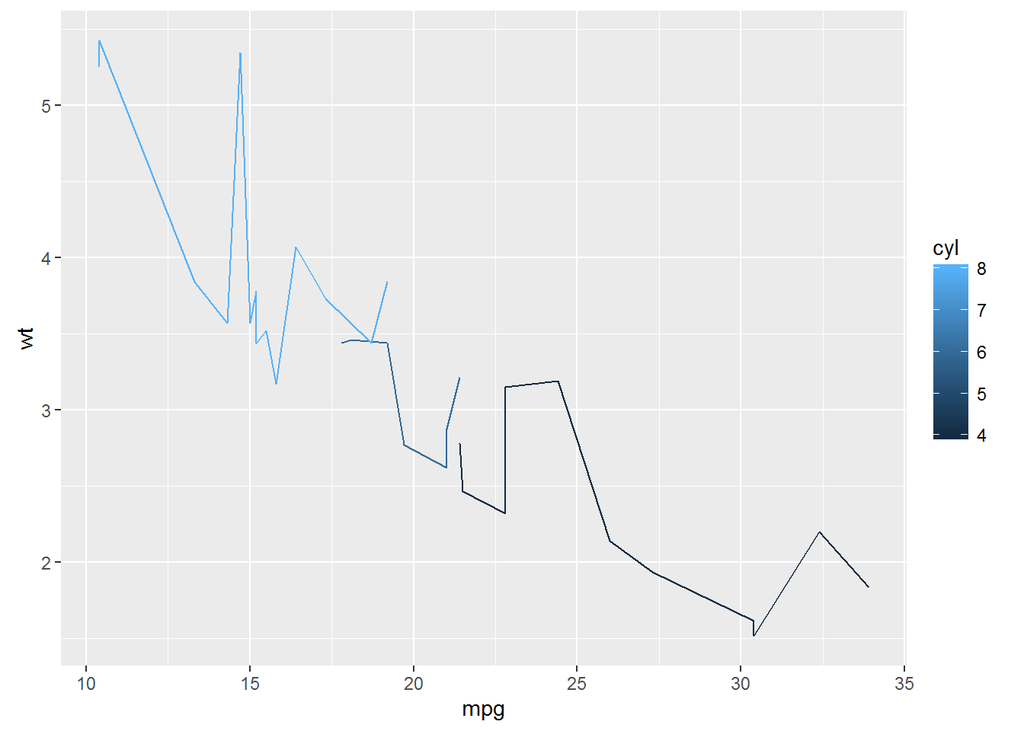

```r
ggplot(data=mtcars, aes(x = mpg, y = wt, group = cyl, colour = cyl)) +
    geom_line() #+
```

```r
    #geom_point()
```

More info on line graphs